# Spotify Top Streamed Songs Analysis 2017 - 2019

Group: 313A

Names: Danny Soulas, Laura Dinh, Torrey Coan, Nicholas Tam

## Introduction

Spotify is one of the most widely used streaming apps in the world with over 381 million users. It is used daily for users to enjoy their music, podcasts, and other forms of audio entertainment. For the purposes of our project, we will focus on Spotify music. The platform has collected data from its millions of users to determine the most popular streamed songs each year. In our project, we use playlists containing these top streamed songs over the course of three years. **These playlists generated by Spotify led us to seek questions about the data; can we discover a relationship between the variables of valence, tempo, and rank?** These songs can rack up over billions of streams, but what makes these songs so appealing? Do specific traits affect a song’s overall rank? We wanted to discover if there were any meaningful relationships between variables in the dataset, specifically between valence, tempo, and rank. More specifically, we were interested in these questions:

- Did the tempo of top streamed songs get faster from 2017 to 2019?
- Did the top streamed songs get happier from 2017 to 2019?
- Can tempo and valence predict rank for the top streamed songs?

Although it may seem songs have gotten faster and happier in the past few years, we did not find any statistically significant evidence that the tempo and happiness of songs have increased from 2017 to 2019. In addition, we failed to find evidence significant enough between valence and rank to predict ranks, however there was evidence to show that the slope of the linear relationship between tempo and ranking is not 0 which can be used as a weak predictor for ranking.

## Background

### About the Data

The Spotify Top Streamed 2017, 2018, and 2019 sets used were created by Nadin Tamer. The data was created by using [the Organize Your Music website](http://organizeyourmusic.playlistmachinery.com/)[^1], a web app that allows users to break down different characteristics of their music consumption. It intakes a Spotify playlist and returns scores of certain variables for each song. Playlists containing the top streamed songs from 2017, 2018, and 2019 were input into the Organize Your Music website and created data sets for each playlist. For each year’s data set, each row is one song, each ordered from lowest ranked to highest rank. The Top Streamed Songs playlists from 2017 and 2018 had 100 songs each while 2019 had 50 songs. Therefore, the data set we used for our project has a total of 250 songs. However, let it be noted that there are 10 songs that appear twice in the data set. This is because there are 7 songs included in both 2017 and 2018, and 3 songs included in 2018 and 2019. We decided to keep these songs in the data sets because they were statistically significant and gave more representation for each year the data was in. We are also assuming that the data sets for each year are independent. In other words, the top streamed songs from one year do not affect the top streamed songs for the other years.

The data sets were uploaded to Kaggle by Nadin Tamer. Here are the links to the three data sets:

- [The Top Streamed Songs for 2017](https://www.kaggle.com/nadintamer/top-tracks-of-2017)[^2]
- [The Top Streamed Songs for 2018](https://www.kaggle.com/nadintamer/top-spotify-tracks-of-2018)[^3]
- [The Top Streamed Songs for 2019](https://www.kaggle.com/nadintamer/top-spotify-tracks-of-2019)[^4]

From these data sets, we specifically examined three variables from the data sets: tempo, valence, and rank.

Tempo is the speed or pace of a given song that is measured in beats per minute. Here are a few tempo indicators that demonstrate the typical tempo range of songs:

Tempo Ranges

| Description | BPM |
| --- | --- |
| Slow and Solemn | 20–40 BPM |
| Slowly | 40–45 BPM |
| Broadly | 45–50 BPM |
| Slow (at ease) | 55–65 BPM |
| Rather Slow | 65–69 BPM |
| Walking Pace | 73–77 BPM |
| Moderate | 86–97 BPM |
| Moderately Fast | 98–109 BPM |
| Fast, Quickly, and Bright | 109–132 BPM |
| Lively and Fast | 132–140 BPM |
| Extremely Fast | 168–177 BPM |
| Even Faster | 178 BPM and over |

For more about tempo indicators [click here](https://symphonynovascotia.ca/faqs/symphony-101/how-do-musicians-know-how-fast-to-play-a-piece-and-why-are-the-terms-in-italian/)[^5]

Valence is specific to Spotify’s API. It describes the musical positiveness conveyed by a track and is measure on a scale of 0 to 1. Tracks with a higher valence sound more positive while tracks with lower valence sound more sad.

For more information about valence, here are links that provide more information:

- [Valence Definition](https://www.theverge.com/tldr/2018/2/5/16974194/spotify-recommendation-algorithm-playlist-hack-nelson)[^6]
- [How a Computer Determines Valence](https://web.archive.org/web/20170422195736/http://blog.echonest.com/post/66097438564/plotting-musics-emotional-valence-1950-2013)[^7]

To conclude, rank represents how many streams a song has. A rank of 1 means the song was the top streamed song for the given year, a rank of 2 means the song was the second top streamed song for the given year, and so on. Therefore, lower rank means greater number of streams, and conversely, higher rank means lower number of streams.

### Methods

In the rest of this report, we will be running unpaired two-sample T tests and creating linear regression models to examine the trends of valence and rank across the three years.

#### Variables from Data

Key Variables from the Spotify Top Streamed Songs Data

| Name | Description |
| --- | --- |
| name | A string of the song name |
| artists | A string of the artist(s)’ name(s) |
| valence | A real number between 0 and 1 that represents the happiness of a song |
| tempo | A real number greater than or equal to 0 that represents the speed at which a passage of music is played. It is measured in beats per minute (BPM) |
| rank | The popularity of the song for the year |

## Analysis

### Did the top streamed songs get faster from 2017 to 2019?

First, we summarize the tempo data for all three years.

Tempo Summary

| year | n | mean | sd | max | min |
| --- | --- | --- | --- | --- | --- |
| 2017 | 100 | 119.2025 | 27.95293 | 199.864 | 75.016 |
| 2018 | 100 | 119.9042 | 28.79598 | 198.075 | 64.934 |
| 2019 | 50 | 120.4257 | 28.74086 | 179.974 | 71.105 |

- $year$ is the year the songs charted in the Spotify top streamed songs
- $n$ is the number of songs
- $mean$ is the mean tempo for the given year
- $sd$ is the standard deviation of the songs’ tempo
- $max$ is the song with the fastest tempo for the year
- $min$ is the song with the slowest tempo for the year

#### T Tests

We ran an unpaired two-sample T Test (Two Mean Test) of tempos between 2017 and 2018:

Tempo between 2017 and 2018 for Top 5 Songs

| rank | 2017 | 2018 |
| --- | --- | --- |
| 1 | 95.977 | 77.169 |
| 2 | 88.931 | 75.023 |
| 3 | 177.833 | 159.847 |
| 4 | 103.019 | 140.124 |
| 5 | 80.924 | 91.030 |

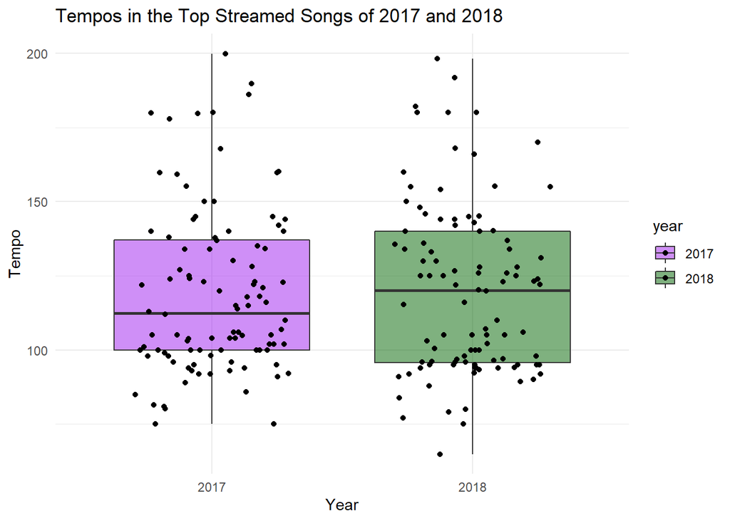

**Mean Tempos for Top Songs (2017, 2018)**. The black dots represent the tempos of the songs.

##### Model

We have two independent samples of songs, one for 2017 and the other for 2018

- $X_i \sim F_1(\mu_1, \sigma_1), \quad i = 1, \ldots, n_1$
- $Y_i \sim F_2(\mu_2, \sigma_2), \quad i = 1, \ldots, n_2$

##### Hypothesis Test

$$H_0: \mu_1 = \mu_2 \\
H_a: \mu_1 < \mu_2$$

##### Summary of the T-Test:

Unpaired T Test Results

| mean_2017 | mean_2018 | t | df | pvalue |
| --- | --- | --- | --- | --- |
| 119.2025 | 119.9042 | -0.1748531 | 197.8254 | 0.4306869 |

We have no evidence from the data that the mean tempo for the top streamed songs of 2017 is different than the mean tempo for the top streamed songs of 2018 (p = 0.431, unpaired t-test, df = 197.825)

Let’s run the same unpaired t-test for 2018 and 2019:

Tempo between 2018 and 2019 for Top 5 Songs

| rank | 2018 | 2019 |
| --- | --- | --- |
| 1 | 77.169 | 116.967 |
| 2 | 75.023 | 135.128 |
| 3 | 159.847 | 89.960 |
| 4 | 140.124 | 140.048 |
| 5 | 91.030 | 136.041 |

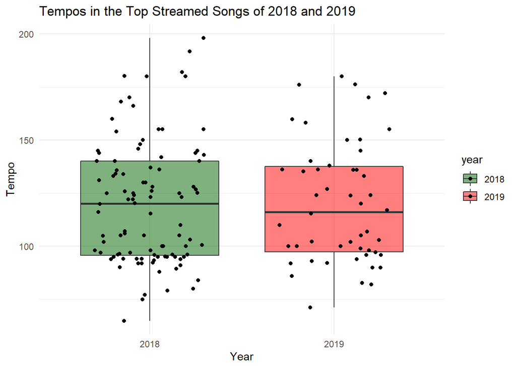

**Mean Tempos for Top Songs (2018, 2019)**. The black dots represent the tempos of the songs.

##### Model

- $X_i \sim F_1(\mu_1, \sigma_1), \quad i = 1, \ldots, n_1$
- $Y_i \sim F_2(\mu_2, \sigma_2), \quad i = 1, \ldots, n_2$

##### Hypothesis Test

$$H_0: \mu_1 = \mu_2 \\
H_a: \mu_1 < \mu_2$$

##### Summary of the T-Test:

Unpaired T Test Results

| mean_2018 | mean_2019 | t | df | pvalue |
| --- | --- | --- | --- | --- |
| 119.9042 | 120.4257 | -0.1046967 | 98.27816 | 0.4584149 |

We have no evidence from the data that the mean tempo for the top streamed songs of 2018 is different than the mean tempo for the top streamed songs of 2019 (p = 0.458, unpaired t-test, df = 98.278)

Lastly, let’s check if there is a difference between the means for 2017 and 2019:

Tempo between 2017 and 2019 for Top 5 Songs

| rank | 2017 | 2019 |
| --- | --- | --- |
| 1 | 95.977 | 116.967 |
| 2 | 88.931 | 135.128 |
| 3 | 177.833 | 89.960 |
| 4 | 103.019 | 140.048 |
| 5 | 80.924 | 136.041 |

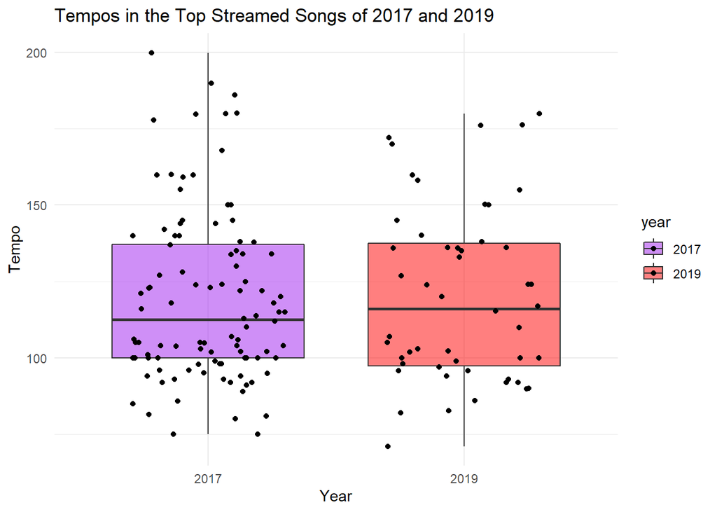

**Mean Tempos for Top Songs (2017, 2019)**. The black dots represent the tempos of the songs.

##### Model

- $X_i \sim F_1(\mu_1, \sigma_1), \quad i = 1, \ldots, n_1$
- $Y_i \sim F_2(\mu_2, \sigma_2), \quad i = 1, \ldots, n_2$

##### Hypothesis Test

$$H_0: \mu_1 = \mu_2 \\
H_a: \mu_1 < \mu_2$$

##### Summary of the T-Test:

Unpaired T Test Results

| mean_2017 | mean_2019 | t | df | pvalue |
| --- | --- | --- | --- | --- |
| 119.2025 | 120.4257 | -0.2479713 | 95.71398 | 0.4023439 |

We have no evidence from the data that the mean tempo for the top streamed songs of 2017 is different than the mean tempo for the top streamed songs of 2019 (p = 0.402, unpaired t-test, df = 95.713)

#### Correlations

Can tempo predict rank for a top streamed song in the 2017 to 2019 data?

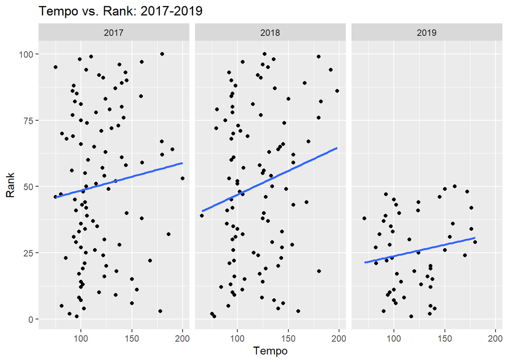

The black dots represent the tempos of the songs. The blue line is a fitted linear model

For each year the correlations were:

- 2017: $r$ = 0.100
- 2018: $r$ = 0.179
- 2019: $r$ = 0.170

The correlation for all top streamed songs from 2017-2019:

- $r$ = 0.127

#### Linear Regression

It looks like there may be a relationship between the two - let’s find the linear regression model using tempo to estimate rank, and see the significance of tempo as a predictor.

##### Hypothesis Test

Let $B_1$ be the slope of the linear regression model between tempo and rank.

$$H_0: B_1 = 0 \\
H_a: B_1 \ne 0$$

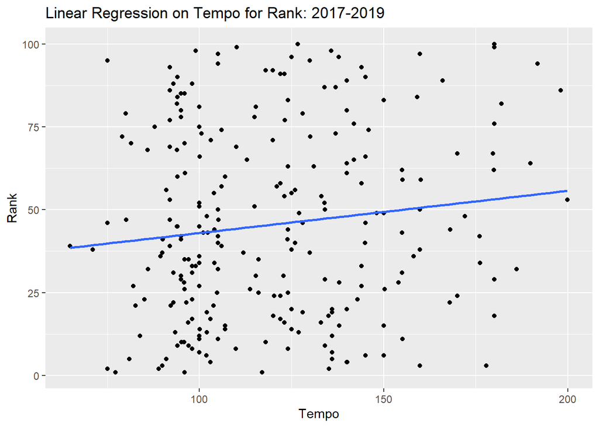

This graph plots all the top streamed songs from 2017, 2018 and 2019. The black dots represent a single song. The blue line represents a fitted linear model

Linear Regression P-Value

| p.value |
| --- |
| 0.0456114 |

Linear Regression Summary

| intercept | b1 | regression_on |
| --- | --- | --- |
| 30.26949 | 0.1272095 | tempo |

With a p-value = 0.046 < 0.05, we reject the null hypothesis and have evidence to support the alternative that the true slope between tempo and rank is nonzero. We have evidence that tempo is a statistically significant predictor of rank.

### Did the top streamed songs get happier from 2017 to 2019?

Now, we’ll summarize the valence data for all three years.

Valence Summary

| year | n | mean | sd | max | min |
| --- | --- | --- | --- | --- | --- |
| 2017 | 100 | 0.517049 | 0.2164361 | 0.966 | 0.0862 |
| 2018 | 100 | 0.484443 | 0.2061452 | 0.931 | 0.0796 |
| 2019 | 50 | 0.490460 | 0.2191437 | 0.952 | 0.1200 |

- $year$ is the year the songs are from
- $n$ is the number of songs
- $mean$ is the mean valence for the given year
- $sd$ is the standard deviation of the songs’ valence
- $max$ is the song with the highest valence for the year
- $min$ is the song with the lowest valence for the year

#### T Tests

We ran an unpaired two-sample T Test of valences between 2017 and 2018:

Valence between 2017 and 2018 for Top 5 Songs

| rank | 2017 | 2018 |
| --- | --- | --- |
| 1 | 0.931 | 0.357 |
| 2 | 0.813 | 0.473 |
| 3 | 0.846 | 0.140 |
| 4 | 0.446 | 0.439 |
| 5 | 0.811 | 0.350 |

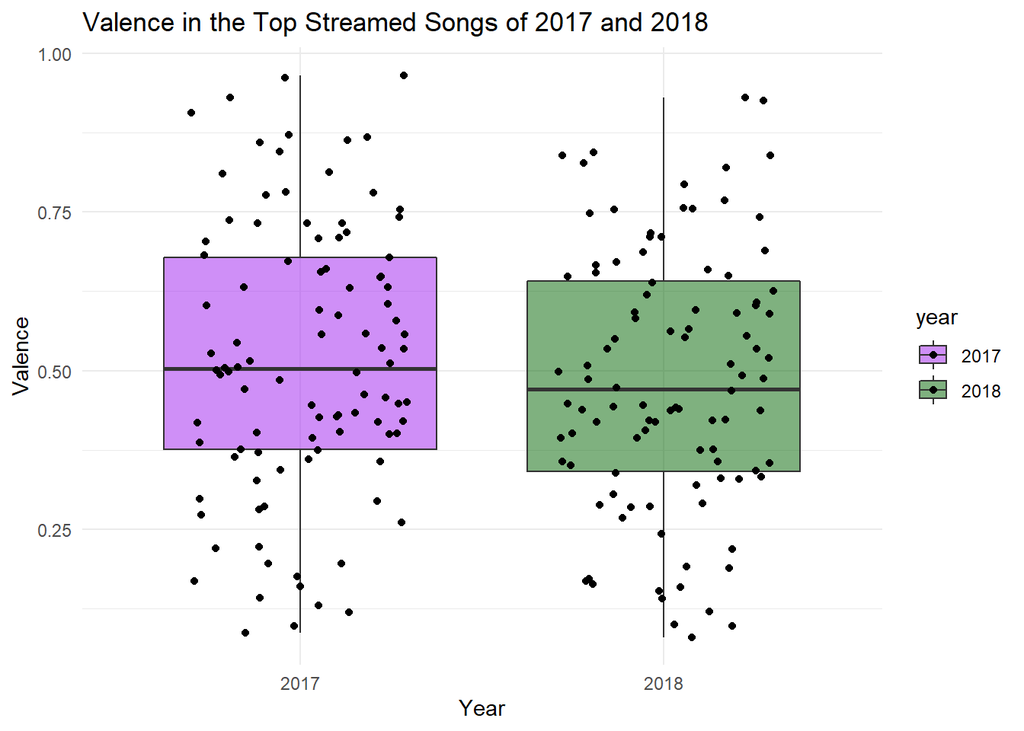

**Mean Valence for Top Songs (2017, 2018)**. The black dots represent the valence for each of the songs.

##### Model

- $X_i \sim F_1(\mu_1, \sigma_1), \quad i = 1, \ldots, n_1$
- $Y_i \sim F_2(\mu_2, \sigma_2), \quad i = 1, \ldots, n_2$

##### Hypothesis Test

$$H_0: \mu_1 = \mu_2 \\
H_a: \mu_1 < \mu_2$$

##### Summary of the T-Test:

Unpaired T Test Results

| mean_2017 | mean_2018 | t | df | pvalue |
| --- | --- | --- | --- | --- |
| 0.517049 | 0.484443 | 1.090871 | 197.532 | 0.8616709 |

We have no evidence from the data that the mean valence for the top streamed songs of 2017 is different than the mean valence for the top streamed songs of 2018 (p = 0.862, unpaired t-test, df = 197.532)

Let’s run the same unpaired t-test for 2018 and 2019:

Valence between 2018 and 2019 for Top 5 Songs

| rank | 2018 | 2019 |
| --- | --- | --- |
| 1 | 0.357 | 0.749 |
| 2 | 0.473 | 0.562 |
| 3 | 0.140 | 0.925 |
| 4 | 0.439 | 0.327 |
| 5 | 0.350 | 0.639 |

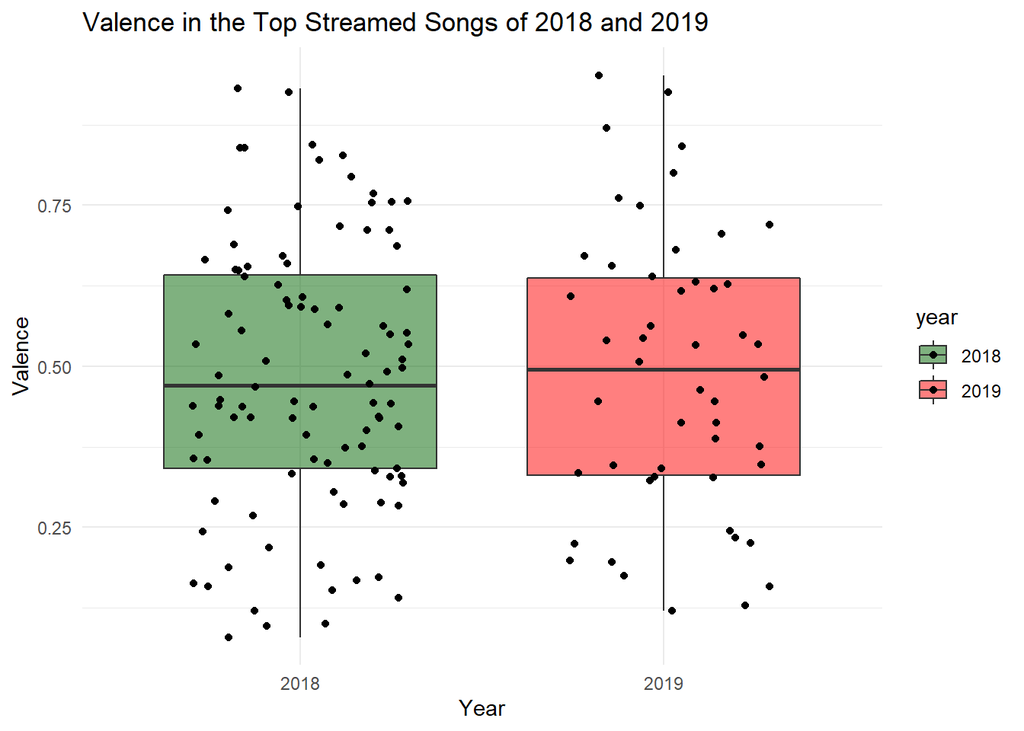

##### Model

- $X_i \sim F_1(\mu_1, \sigma_1), \quad i = 1, \ldots, n_1$
- $Y_i \sim F_2(\mu_2, \sigma_2), \quad i = 1, \ldots, n_2$

##### Hypothesis Test

$$H_0: \mu_1 = \mu_2 \\
H_a: \mu_1 < \mu_2$$

##### Summary of the T-Test:

Unpaired T Test Results

| mean_2018 | mean_2019 | t | df | pvalue |
| --- | --- | --- | --- | --- |
| 0.484443 | 0.49046 | -0.161654 | 92.94607 | 0.4359646 |

We have no evidence from the data that the mean valence for the top streamed songs of 2018 is different than the mean valence for the top streamed songs of 2019 (p = 0.436, unpaired t-test, df = 92.946)

Lastly, let’s check if there is a difference between the means for 2017 and 2019:

Valence between 2017 and 2019 for Top 5 Songs

| rank | 2017 | 2019 |
| --- | --- | --- |
| 1 | 0.931 | 0.749 |
| 2 | 0.813 | 0.562 |
| 3 | 0.846 | 0.925 |
| 4 | 0.446 | 0.327 |
| 5 | 0.811 | 0.639 |

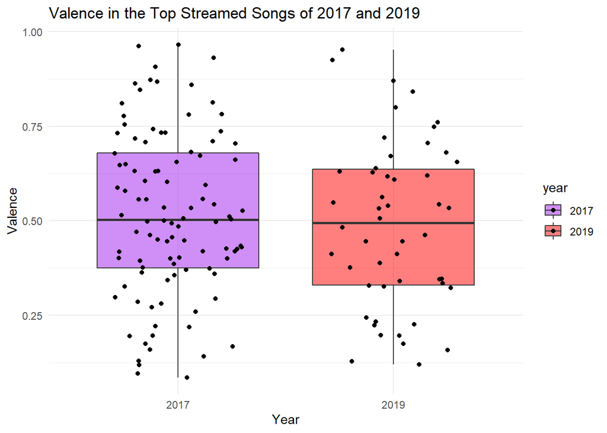

**Mean Valence for Top Songs (2017, 2019)**. The black dots represent the valence for each of the songs.

##### Model

- $X_i \sim F_1(\mu_1, \sigma_1), \quad i = 1, \ldots, n_1$
- $Y_i \sim F_2(\mu_2, \sigma_2), \quad i = 1, \ldots, n_2$

##### Hypothesis Test

$$H_0: \mu_1 = \mu_2 \\
H_a: \mu_1 < \mu_2$$

##### Summary of the T-Test:

Unpaired T Test Results

| mean_2017 | mean_2019 | t | df | pvalue |
| --- | --- | --- | --- | --- |
| 0.517049 | 0.49046 | 0.7033918 | 97.02872 | 0.758252 |

We have no evidence from the data that the mean valence for the top streamed songs of 2017 is different than the mean valence for the top streamed songs of 2019 (p = 0.758, unpaired t-test, df = 97.029)

#### Correlations

Can valence predict rank for a top streamed song in the 2017 to 2019 data?

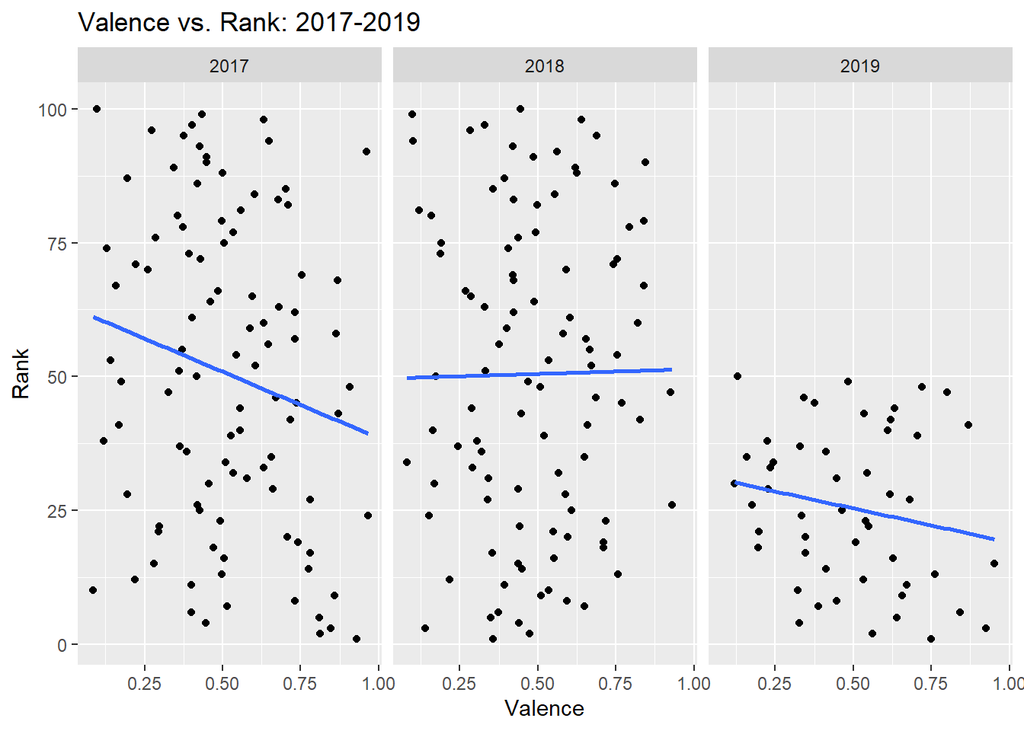

The black dots represent the valence of the songs. The blue line is a fitted linear model

For each year the correlations were:

- 2017: $r$ = -0.185
- 2018: $r$ = 0.013
- 2019: $r$ = -0.191

The correlation for all top streamed songs from 2017-2019:

- $r$ = -0.084

#### Linear Regression

Let’s check to see if valence is a statistically significant predictor of rank using a linear regression model.

##### Hypothesis Test

Let $B_1$ be the slope of the linear regression model between valence and rank.

$$H_0: B_1 = 0 \\
H_a: B_1 \ne 0$$

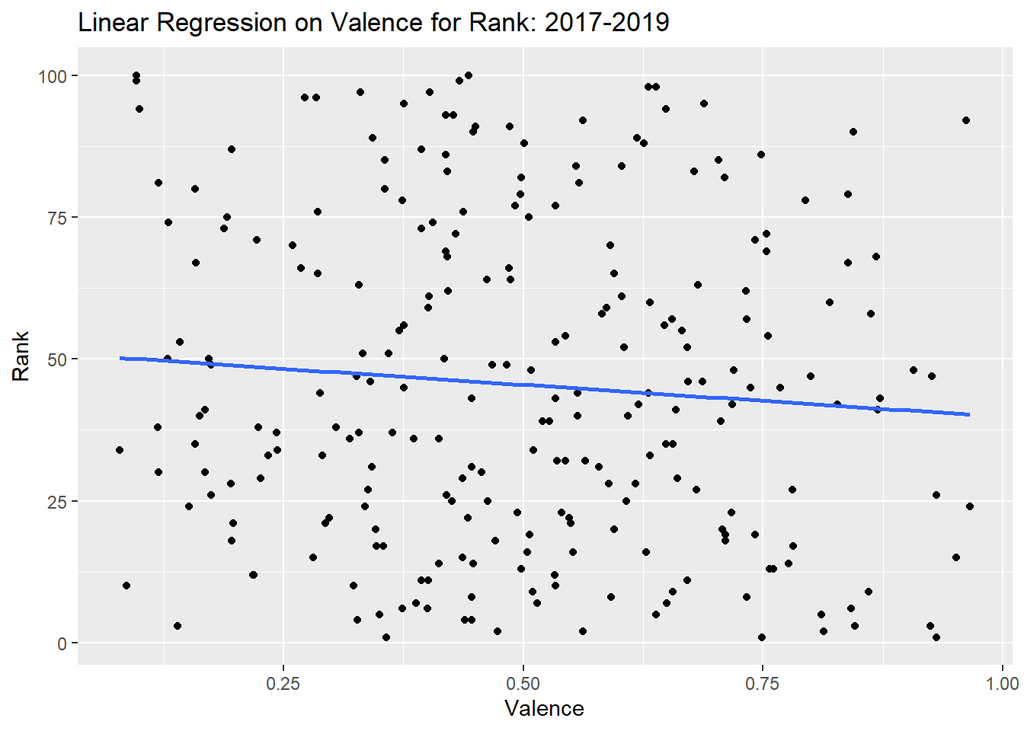

This graph plots all the top streamed songs from 2017, 2018 and 2019. The black dots represent a single song. The blue line represents a fitted linear model

Linear Regression P-Value

| p.value |
| --- |
| 0.1843749 |

Linear Regression Summary

| intercept | b1 | regression_on |
| --- | --- | --- |
| 51.12778 | -11.28516 | valence |

With a p value = 0.18 > 0.05, we fail to reject the null hypothesis that a the linear regression model has a coefficient for valence of 0.

## Discussion

The average tempo of songs across the three years increased approximately 0.6 beats per minute faster for every year. After performing the unpaired two-sample t-tests, we found the p-values for each year were approximately 0.4. In other words, that this increase in the mean was not statistically significant. If we look at tempo indicators defined in the “about the data section,” we can see that the intervals of tempo indicators are much larger than 0.6 beats per minute. We would have to have a much larger jump between means for the increase to be statistically significant.

In comparison, the average valence of songs did not increase like we expected and did not display any noticeable trends. All the p-values for the unpaired two-sample t tests were greater than 0.4, meaning there was no evidence that the mean valence increased between 2017 and 2018, 2018 and 2019, and 2017 to 2019.

For the relationship between tempo and rank, the correlation coefficients were very weak, approximately 0.1 for every year in our sample. However, the hypothesis test we performed showed that tempo and rank’s linear regression model had a slope that was nonzero. We can use the linear regression model to predict the rank based on the tempo; however, because the relationship is weak, the predictions may not be very accurate. To summarize, changes in tempo are associated with changes in rank, as the p-value for the coefficient of tempo (0.045) was beneath our threshold (0.05). This means it is unlikely our data could have occurred under the null hypothesis that the coefficient for tempo was 0. Per our linear regression, we see that for the top streamed Spotify songs from 2017-2019, if beats per minute increases by 1, we can expect rank to increase by about 0.13.

The relationship between valence and rank did not have the same result. The correlation coefficients were very weak. Our hypothesis test found that there was no evidence that the slope of the linear regression line was not 0. Unless we significantly raise alpha, we should not use valence to estimate the rank of top streamed Spotify songs. Changes in valence are not associated with changes in rank, since the p-value associated with the coefficient of valence in the linear regression (p-value = 0.18) was greater than our threshold (alpha = 0.05).

### Potential Shortcomings

#### Data accuracy

The data is directly extracted from the Spotify app and Spotify’s official playlists. The data should be considered as accurate as possible. However, since some of the data is with regards to some variables that are harder to measure like valence, danceability and energy.

A music professional measured the valence of a sample of songs, applying a set of rules. To apply the same rules to all songs in Spotify’s library, Spotify used a machine learning algorithm to train on the sample songs and learn the rules set by the music professionals. This algorithm then applied these learned rules and applied them to all of the songs on Spotify. Even though there was only one person measuring valence, which reduced variability if multiple people were measuring songs, valence is still very subjective and ambiguous. It is unknown what rules the music professional used to measure songs.

#### Missing key data

The dataset for year 2019 only consists of 50 of the top 100 songs. We would have had more accurate results if we were able to have the top 100.

#### Sample not representative

Since the 3 data sets used were from 2017 - 2019, the sample size could have been two small and the years are directly next to each other. Since the sample data set is limited, it may not be reasonable to compare the data obtained to years outside of the range since it would be using extrapolation, which could be inaccurate. Moreover, with Covid, music tastes could have changed since 2019 and our sample data when compared to years after could be inaccurate.

#### Key assumptions may not hold

In our background, we assumed that the data sets were independent. The top streamed songs from one year did not affect the top streamed songs of the other two years. This assumption is not necessarily true. Some top songs are repeated across the three years. This means that the data from year to year is dependent and the unpaired two-sample t-tests that were run might not be entirely accurate.

## Conclusion

In conclusion, we have found that there was no evidence that the tempo and happiness of songs have increased from 2017 to 2019. While the increase in the mean of tempo was not statistically significant, we did find that the tempo was a weak predictor of rank within the top streamed songs of 2017, 2018, and 2019.

## References

[^1]: Organize Your Music: (http://organizeyourmusic.playlistmachinery.com/)
[^2]: Dataset for 2017: (https://www.kaggle.com/nadintamer/top-tracks-of-2017)
[^3]: Dataset for 2018: (https://www.kaggle.com/nadintamer/top-spotify-tracks-of-2018)
[^4]: Dataset for 2019: (https://www.kaggle.com/nadintamer/top-spotify-tracks-of-2019)
[^5]: Tempo Definitions: (https://symphonynovascotia.ca/faqs/symphony-101/how-do-musicians-know-how-fast-to-play-a-piece-and-why-are-the-terms-in-italian/)
[^6]: Term Definitions: (https://www.theverge.com/tldr/2018/2/5/16974194/spotify-recommendation-algorithm-playlist-hack-nelson)
[^7]: Where valence comes from: (https://web.archive.org/web/20170422195736/http://blog.echonest.com/post/66097438564/plotting-musics-emotional-valence-1950-2013)